# Covid-19 Pandemic Impact on Bikeshare at Boston

## Introduction

> Coronavirus has had a large-scale impact on transportation. This study attempts to assess the effects of COVID-19 on biking. Bikeshare data was used to understand the impacts of COVID-19 during the initial wave of the disease on biking in Boston  
> The study period was split into two phases—no COVID-19 phase at the secound quarted of 2019, cases increasing phase at the secound quarter of 2020.  
> The Original data extracted from https://www.bluebikes.com/system-data

## Preliminary Wrangling

> Dataset cover the Bikeshare data in Boston in two duration  
> secound Quarter of 2019 (April , May and June ) before Covid-19  
> and the secound Quarter of 2020 (April , May and June ) during Covid-19  
> Dataset Original structural is as follow :  
> Trip Duration (seconds)  
> Start Time and Date  
> Stop Time and Date  
> Start Station Name & ID  
> End Station Name & ID  
> Bike ID  
> User Type (Casual = Single Trip or Day Pass user; Member = Annual or Monthly Member)  
> Birth Year  
> Gender, self-reported by member (Zero=unknown; 1=male; 2=female)

### Data Wrangling

> 1. Gather the data from the website and create two data frames for each period (2Q of 2019 & 2Q of 2020)
> 2. Drop un needed columns
> 3. Convert start time and stop time to Datetime type
> 4. Extract (Month , Day of week and Hour) from start time column
> 5. Check for duplicates
> 6. Check for Null values
> 7. Replace the "other" in gender with male or female based on the original porpotion
> 8. fill the null values in gender and birth date with the same porpotion of the original data
> 9. Create a new column for each period
> 10. Creat a trip column form start station and end station
> 11. Combine the two datasets in df to start the Exploration phase

```python
# import all packages and set plots to be embedded inline
import numpy as np
import pandas as pd
import matplotlib.pyplot as plt
import seaborn as sb

%matplotlib inline
```

> Load the first Data Frame for the secound Quarter of 2019 (Before Covid - 19)

```python
#load data April 2019
df_april_2019 = pd.read_csv('201904-bluebikes-tripdata.csv')
```

```python
#load data May 2019
df_may_2019 = pd.read_csv('201905-bluebikes-tripdata.csv')
```

```python
#load data June 2019
df_june_2019 = pd.read_csv('201906-bluebikes-tripdata.csv')
```

```python
#Concat the secound quarter of 2019  (before Covid-19) in new data frame
df_Q2_2019 = pd.concat([df_april_2019 , df_may_2019 , df_june_2019] , ignore_index = True)
```

```python
#check the structural of the data frame
df_Q2_2019.head(1)
```

|  | tripduration | starttime | stoptime | start station id | start station name | start station latitude | start station longitude | end station id | end station name | end station latitude | end station longitude | bikeid | usertype | birth year | gender |
| --- | --- | --- | --- | --- | --- | --- | --- | --- | --- | --- | --- | --- | --- | --- | --- |
| 0 | 3363 | 2019-04-01 00:04:38.1400 | 2019-04-01 01:00:41.6390 | 8 | Union Square - Brighton Ave at Cambridge St | 42.353334 | -71.137313 | 8 | Union Square - Brighton Ave at Cambridge St | 42.353334 | -71.137313 | 3736 | Customer | 1969 | 0 |

```python
df_Q2_2019.info()
```

```
<class 'pandas.core.frame.DataFrame'>
RangeIndex: 663861 entries, 0 to 663860
Data columns (total 15 columns):
 #   Column                   Non-Null Count   Dtype
---  ------                   --------------   -----
 0   tripduration             663861 non-null  int64
 1   starttime                663861 non-null  object
 2   stoptime                 663861 non-null  object
 3   start station id         663861 non-null  int64
 4   start station name       663861 non-null  object
 5   start station latitude   663861 non-null  float64
 6   start station longitude  663861 non-null  float64
 7   end station id           663861 non-null  int64
 8   end station name         663861 non-null  object
 9   end station latitude     663861 non-null  float64
 10  end station longitude    663861 non-null  float64
 11  bikeid                   663861 non-null  int64
 12  usertype                 663861 non-null  object
 13  birth year               663861 non-null  int64
 14  gender                   663861 non-null  int64
dtypes: float64(4), int64(6), object(5)
memory usage: 76.0+ MB
```

```python
# Drop the un-needed columns
df_Q2_2019 = df_Q2_2019.drop(['start station latitude','start station longitude',
                              'end station latitude', 'end station longitude',
                              'start station id' , 'end station id' ] , axis = 1)
```

```python
# Convert the start and stop time to datetime
df_Q2_2019['starttime'] = pd.to_datetime(df_Q2_2019['starttime'])
df_Q2_2019['stoptime'] = pd.to_datetime(df_Q2_2019['stoptime'])
```

```python
# Convert the bike Id to srting
df_Q2_2019 =df_Q2_2019.astype({'bikeid': 'str'})
```

```python
# Extract month , day of week and hour from start date
df_Q2_2019['month'] = df_Q2_2019['starttime'].dt.month
df_Q2_2019['day'] = df_Q2_2019['starttime'].dt.dayofweek
df_Q2_2019['hour'] = df_Q2_2019['starttime'].dt.hour
```

```python
df_Q2_2019['month'] = df_Q2_2019['month'].replace({4 :'April' , 5 : 'May' , 6:'June'} )
df_Q2_2019['day'] = df_Q2_2019['day'].replace({0:'Monday' , 1:'Tuesday' , 2:'Wednesday' ,
                                               3:'Thursday' , 4:'Friday' , 5:'Saturday ' , 6:'Sunday'})
```

```python
df_Q2_2019.nunique()
```

```
tripduration           11480
starttime             663806
stoptime              663810
start station name       296
end station name         301
bikeid                  3077
usertype                   2
birth year                77
gender                     3
month                      3
day                        7
hour                      24
dtype: int64
```

```python
#check duplicates
df_Q2_2019.duplicated().sum()
```

```
0
```

```python
# Check Null values
df_Q2_2019.isnull().sum()
```

```
tripduration          0
starttime             0
stoptime              0
start station name    0
end station name      0
bikeid                0
usertype              0
birth year            0
gender                0
month                 0
day                   0
hour                  0
dtype: int64
```

```python
# Check the Gender column
df_Q2_2019.gender.value_counts()
```

```
1    420303
2    152882
0     90676
Name: gender, dtype: int64
```

```python
# 90676 unknown gender - will be replaced based on the porpotion of the male and female
df_Q2_2019.gender = df_Q2_2019.gender.replace (0 , np.nan)
```

```python
# Find the porpotion of the male and female
df_Q2_2019.gender.value_counts(normalize  = True)
```

```
1.0    0.733276
2.0    0.266724
Name: gender, dtype: float64
```

```python
# Fill the Nan with the same porpotion
df_Q2_2019.gender = df_Q2_2019.gender.apply(lambda x: np.random.choice([1,2] , p=[0.67 , 0.33]) if np.isnan(x) else x)
# Check
df_Q2_2019.gender.value_counts(normalize  = True)
```

```
1.0    0.725126
2.0    0.274874
Name: gender, dtype: float64
```

```python
df_Q2_2019['gender'] = df_Q2_2019['gender'].replace({1 :'Male' , 2 : 'Female'} )
```

```python
df_Q2_2019.shape
```

```
(663861, 12)
```

```python
# Check the quantitiative data
df_Q2_2019.describe()
```

|  | tripduration | birth year | hour |
| --- | --- | --- | --- |
| count | 6.638610e+05 | 663861.000000 | 663861.000000 |
| mean | 2.262215e+03 | 1983.756991 | 13.985861 |
| std | 9.666412e+04 | 11.614128 | 4.777382 |
| min | 6.100000e+01 | 1886.000000 | 0.000000 |
| 25% | 4.380000e+02 | 1973.000000 | 10.000000 |
| 50% | 7.550000e+02 | 1988.000000 | 15.000000 |
| 75% | 1.275000e+03 | 1993.000000 | 18.000000 |
| max | 4.256714e+07 | 2003.000000 | 23.000000 |

```python
#remove Trip duration outlier
df_Q2_2019 =df_Q2_2019[df_Q2_2019.tripduration <100000]
```

```python
df_Q2_2019.describe()
```

|  | tripduration | birth year | hour |
| --- | --- | --- | --- |
| count | 663146.000000 | 663146.000000 | 663146.000000 |
| mean | 1146.980956 | 1983.765298 | 13.986095 |
| std | 2345.954257 | 11.612021 | 4.775485 |
| min | 61.000000 | 1886.000000 | 0.000000 |
| 25% | 437.000000 | 1973.000000 | 10.000000 |
| 50% | 754.000000 | 1988.000000 | 15.000000 |
| 75% | 1272.000000 | 1993.000000 | 18.000000 |
| max | 99927.000000 | 2003.000000 | 23.000000 |

```python
#discovered odd  min. birth year
(df_Q2_2019['birth year']< 1970).value_counts()
```

```
False    517768
True     145378
Name: birth year, dtype: int64
```

```python
#remove the odd values and replace it with NaN
df_Q2_2019.loc[df_Q2_2019['birth year'] < 1970, 'birth year'] = np.nan
```

```python
# Creat two list of birth date and porpotion to fill the NaN
df_b = pd.DataFrame(df_Q2_2019['birth year'].value_counts(normalize = True).reset_index() )
df_b = df_b.rename(columns = {'index':'year' , 'birth year':'p'})
year = df_b.year.tolist()
p = df_b.p.tolist()
df_b.head()
```

|  | year | p |
| --- | --- | --- |
| 0 | 1994.0 | 0.067215 |
| 1 | 1992.0 | 0.066142 |
| 2 | 1993.0 | 0.064386 |
| 3 | 1995.0 | 0.061603 |
| 4 | 1991.0 | 0.060363 |

```python
# Fill the Nan in
df_Q2_2019['birth year'] = df_Q2_2019['birth year'].apply(lambda x: np.random.choice(year , p=p) if np.isnan(x) else x)
#check
df_Q2_2019['birth year'].value_counts(normalize = True).head()
```

```
1994.0    0.067160
1992.0    0.066070
1993.0    0.064260
1995.0    0.061453
1991.0    0.060598
Name: birth year, dtype: float64
```

```python
# Create a new column for the period
df_Q2_2019['year'] = 'Q2 of 2019'
```

```python
df_Q2_2019['Trip'] = df_Q2_2019['start station name'].str.cat(df_Q2_2019['end station name'].values.astype(str),
                                                              sep=' Going to ')
```

```python
df_Q2_2019.head(1)
```

|  | tripduration | starttime | stoptime | start station name | end station name | bikeid | usertype | birth year | gender | month | day | hour | year | Trip |
| --- | --- | --- | --- | --- | --- | --- | --- | --- | --- | --- | --- | --- | --- | --- |
| 0 | 3363 | 2019-04-01 00:04:38.140 | 2019-04-01 01:00:41.639 | Union Square - Brighton Ave at Cambridge St | Union Square - Brighton Ave at Cambridge St | 3736 | Customer | 1987.0 | Male | April | Monday | 0 | Q2 of 2019 | Union Square - Brighton Ave at Cambridge St Go... |

> Load the first Data Frame for the secound Quarter of 2020 (During Covid - 19)

```python
#load data April 2020
df_april_2020 = pd.read_csv('202004-bluebikes-tripdata.csv')
```

```python
#load data May 2020
df_may_2020 = pd.read_csv('202005-bluebikes-tripdata.csv')
```

```python
#load data June 2020
df_june_2020 = pd.read_csv('202006-bluebikes-tripdata.csv')
```

```python
#Concat the secound quarter of 2019  (before Covid-19) in new data frame
df_Q2_2020 = pd.concat([df_april_2020 , df_may_2020 , df_june_2020] , ignore_index = True)
```

```python
#check the structural of the data frame
df_Q2_2020.head(1)
```

|  | tripduration | starttime | stoptime | start station id | start station name | start station latitude | start station longitude | end station id | end station name | end station latitude | end station longitude | bikeid | usertype | birth year | gender | postal code |
| --- | --- | --- | --- | --- | --- | --- | --- | --- | --- | --- | --- | --- | --- | --- | --- | --- |
| 0 | 297 | 2020-04-01 00:12:27.8580 | 2020-04-01 00:17:25.3980 | 67 | MIT at Mass Ave / Amherst St | 42.3581 | -71.093198 | 179 | MIT Vassar St | 42.355601 | -71.103945 | 2221 | Subscriber | 1991.0 | 1.0 | NaN |

```python
df_Q2_2020.columns
```

```
Index(['tripduration', 'starttime', 'stoptime', 'start station id',
       'start station name', 'start station latitude',
       'start station longitude', 'end station id', 'end station name',
       'end station latitude', 'end station longitude', 'bikeid', 'usertype',
       'birth year', 'gender', 'postal code'],
      dtype='object')
```

```python
df_Q2_2020.info()
```

```
<class 'pandas.core.frame.DataFrame'>
RangeIndex: 363515 entries, 0 to 363514
Data columns (total 16 columns):
 #   Column                   Non-Null Count   Dtype
---  ------                   --------------   -----
 0   tripduration             363515 non-null  int64
 1   starttime                363515 non-null  object
 2   stoptime                 363515 non-null  object
 3   start station id         363515 non-null  int64
 4   start station name       363515 non-null  object
 5   start station latitude   363515 non-null  float64
 6   start station longitude  363515 non-null  float64
 7   end station id           363515 non-null  int64
 8   end station name         363515 non-null  object
 9   end station latitude     363515 non-null  float64
 10  end station longitude    363515 non-null  float64
 11  bikeid                   363515 non-null  int64
 12  usertype                 363515 non-null  object
 13  birth year               46793 non-null   float64
 14  gender                   46793 non-null   float64
 15  postal code              281381 non-null  object
dtypes: float64(6), int64(4), object(6)
memory usage: 44.4+ MB
```

```python
# Drop the un-needed columns
df_Q2_2020 = df_Q2_2020.drop(['start station latitude','start station longitude',
                              'end station latitude', 'end station longitude',
                              'start station id' , 'end station id' , 'postal code' ] , axis = 1)
```

```python
# Convert the start and stop time to datetime
df_Q2_2020['starttime'] = pd.to_datetime(df_Q2_2020['starttime'])
df_Q2_2020['stoptime'] = pd.to_datetime(df_Q2_2020['stoptime'])
```

```python
# Convert the bike Id to srting
df_Q2_2020 =df_Q2_2020.astype({'bikeid': 'str'})
```

```python
# Extract month , day of week and hour from start date
df_Q2_2020['month'] = df_Q2_2020['starttime'].dt.month
df_Q2_2020['day'] = df_Q2_2020['starttime'].dt.dayofweek
df_Q2_2020['hour'] = df_Q2_2020['starttime'].dt.hour
```

```python
df_Q2_2020['month'] = df_Q2_2020['month'].replace({4 :'April' , 5 : 'May' , 6:'June'} )
df_Q2_2020['day'] = df_Q2_2020['day'].replace({0:'Monday' , 1:'Tuesday' , 2:'Wednesday' ,
                                               3:'Thursday' , 4:'Friday' , 5:'Saturday ' , 6:'Sunday'})
```

```python
#check duplicates
df_Q2_2020.duplicated().sum()
```

```
0
```

```python
# Check Null values
df_Q2_2020.isnull().sum()
```

```
tripduration               0
starttime                  0
stoptime                   0
start station name         0
end station name           0
bikeid                     0
usertype                   0
birth year            316722
gender                316722
month                      0
day                        0
hour                       0
dtype: int64
```

data of May 2020 and June 2020 didn't contain the birth year or the gender  
I will use the porportions of the data at April 2020 to complete the missing data

```python
# Check the Gender column
df_Q2_2020.gender.value_counts()
```

```
1.0    26999
2.0    13259
0.0     6535
Name: gender, dtype: int64
```

```python
# 6535 unknown gender - will be replaced pased on the porpotion of the male and female
df_Q2_2020.gender = df_Q2_2020.gender.replace (0 , np.nan)
```

```python
df_Q2_2020.gender.value_counts(normalize = True)
```

```
1.0    0.670649
2.0    0.329351
Name: gender, dtype: float64
```

```python
# 6535 unknown gender in addition to 316722 null value - will be replaced pased on the porpotion of the male and female
df_Q2_2020.gender = df_Q2_2020.gender.apply(lambda x: np.random.choice([1,2] , p=[0.67 , 0.33]) if np.isnan(x) else x)
#check
df_Q2_2020.gender.value_counts(normalize = True)
```

```
1.0    0.670302
2.0    0.329698
Name: gender, dtype: float64
```

```python
df_Q2_2020['gender'] = df_Q2_2020['gender'].replace({1 :'Male' , 2 : 'Female'} )
```

```python
# Check the quantitiative data
df_Q2_2020.describe()
```

|  | tripduration | birth year | hour |
| --- | --- | --- | --- |
| count | 3.635150e+05 | 46793.000000 | 363515.000000 |
| mean | 2.538665e+03 | 1984.169641 | 14.653885 |
| std | 2.703098e+04 | 11.930072 | 4.435130 |
| min | 6.100000e+01 | 1888.000000 | 0.000000 |
| 25% | 6.140000e+02 | 1974.000000 | 12.000000 |
| 50% | 1.120000e+03 | 1988.000000 | 15.000000 |
| 75% | 1.965000e+03 | 1993.000000 | 18.000000 |
| max | 3.733182e+06 | 2003.000000 | 23.000000 |

```python
#remove Trip duration outlier
df_Q2_2020 =df_Q2_2020[df_Q2_2020.tripduration <100000]
```

```python
# Remove the odd value of the birth year
df_Q2_2020.loc[df_Q2_2020['birth year'] < 1970, 'birth year'] = np.nan
```

```python
df_b = pd.DataFrame(df_Q2_2020['birth year'].value_counts(normalize = True).reset_index() )
df_b = df_b.rename(columns = {'index':'year' , 'birth year':'p'})
year = df_b.year.tolist()
p = df_b.p.tolist()
df_b.head()
```

|  | year | p |
| --- | --- | --- |
| 0 | 1992.0 | 0.084225 |
| 1 | 1995.0 | 0.071786 |
| 2 | 1994.0 | 0.069519 |
| 3 | 1991.0 | 0.067667 |
| 4 | 1993.0 | 0.064240 |

```python
# Fill the Nan in
df_Q2_2020['birth year'] = df_Q2_2020['birth year'].apply(lambda x: np.random.choice(year , p=p) if np.isnan(x) else x)
#check
df_Q2_2020['birth year'].value_counts(normalize = True).head()
```

```
1992.0    0.084077
1995.0    0.071947
1994.0    0.069718
1991.0    0.067368
1993.0    0.063929
Name: birth year, dtype: float64
```

```python
#Check
df_Q2_2020['birth year'].isna().sum()
```

```
0
```

```python
# Create a new column for the period
df_Q2_2020['year'] = 'Q2 of 2020'
```

```python
df_Q2_2020['Trip'] = df_Q2_2020['start station name'].str.cat(df_Q2_2020['end station name'].values.astype(str),
                                                              sep=' Going to ')
```

```python
df_Q2_2020.head(1)
```

|  | tripduration | starttime | stoptime | start station name | end station name | bikeid | usertype | birth year | gender | month | day | hour | year | Trip |
| --- | --- | --- | --- | --- | --- | --- | --- | --- | --- | --- | --- | --- | --- | --- |
| 0 | 297 | 2020-04-01 00:12:27.858 | 2020-04-01 00:17:25.398 | MIT at Mass Ave / Amherst St | MIT Vassar St | 2221 | Subscriber | 1991.0 | Male | April | Wednesday | 0 | Q2 of 2020 | MIT at Mass Ave / Amherst St Going to MIT Vass... |

> Combine the two datasets in df contain the two periods

```python
df  = pd.concat([df_Q2_2019 , df_Q2_2020 ] , ignore_index = True)
df.sample(3)
```

|  | tripduration | starttime | stoptime | start station name | end station name | bikeid | usertype | birth year | gender | month | day | hour | year | Trip |
| --- | --- | --- | --- | --- | --- | --- | --- | --- | --- | --- | --- | --- | --- | --- |
| 511545 | 887 | 2019-06-14 13:02:22.356 | 2019-06-14 13:17:09.575 | Beacon St at Massachusetts Ave | Boylston St at Fairfield St | 3688 | Customer | 1994.0 | Male | June | Friday | 13 | Q2 of 2019 | Beacon St at Massachusetts Ave Going to Boylst... |
| 550298 | 1035 | 2019-06-19 07:12:24.625 | 2019-06-19 07:29:40.415 | Washington St at Rutland St | One Memorial Drive | 2048 | Subscriber | 1984.0 | Male | June | Wednesday | 7 | Q2 of 2019 | Washington St at Rutland St Going to One Memor... |
| 232300 | 485 | 2019-05-10 16:25:12.964 | 2019-05-10 16:33:18.774 | Brighton Center - Washington St at Cambridge St | Allston Green District - Griggs St at Commonwe... | 2122 | Subscriber | 1987.0 | Male | May | Friday | 16 | Q2 of 2019 | Brighton Center - Washington St at Cambridge S... |

```python
df.shape
```

```
(1026065, 14)
```

```python
df.to_csv('combinedf')
df_Q2_2019.to_csv('2019df')
df_Q2_2020.to_csv('2020df')
```

### What is the structure of your dataset?

> The dataset showing the information of bike share trips in Boston in two period of times  
> (secound quarter of 2019 and secound quareter of 2020)  
> consist of 14 column covering ( trip duration , trip distination , number of trips and user information)  
> distibuted in 1,026,065 rows  
> tripduration - quantitative continuous variable  
> the remaining columns are categorical nominal variable  
> ('start station name','end station name', 'bikeid', 'usertype', 'birth year', 'gender','month', 'day', 'hour', 'year', 'Trip')

### What is/are the main feature(s) of interest in your dataset?

> Total number of trips variables before and during the pandemic  
> and features effecting trips duration

### What features in the dataset do you think will help support your investigation into your feature(s) of interest?

> user information (gender , user type , birth year)  
> Trip information (start station , trip)

## Univariate Exploration

> In this section, I will investigate distributions of individual variables.  
> I will use histograms for the Quantitative continuous variable  
> and Count plot bars for the categorical nominal variable

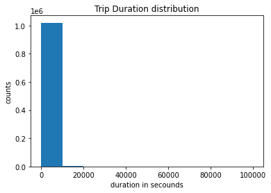

```python
# plot histogram for tripduration
plt.hist(df['tripduration']);
plt.title ('Trip Duration distribution');
plt.xlabel('duration in secounds');
plt.ylabel('counts');
```

(positive skewed )there's log tail in the destribution , so i will put it in a (x) log scale instead

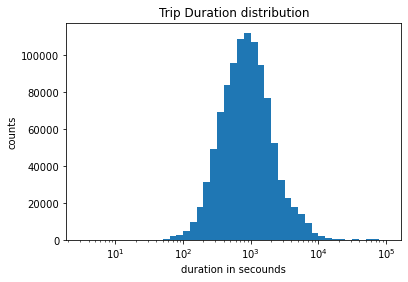

```python
log_binsize=0.1
bins =10** np.arange(0.5, np.log10(df['tripduration'].max())+ log_binsize, log_binsize)

plt.hist(df['tripduration'] , bins=bins);
plt.title ('Trip Duration distribution');
plt.xlabel('duration in secounds');
plt.ylabel('counts');
plt.xscale('log')
```

the most of trip duration is around 1100 secound (around 20 min)  
unimodal and narrower than the normal distribution

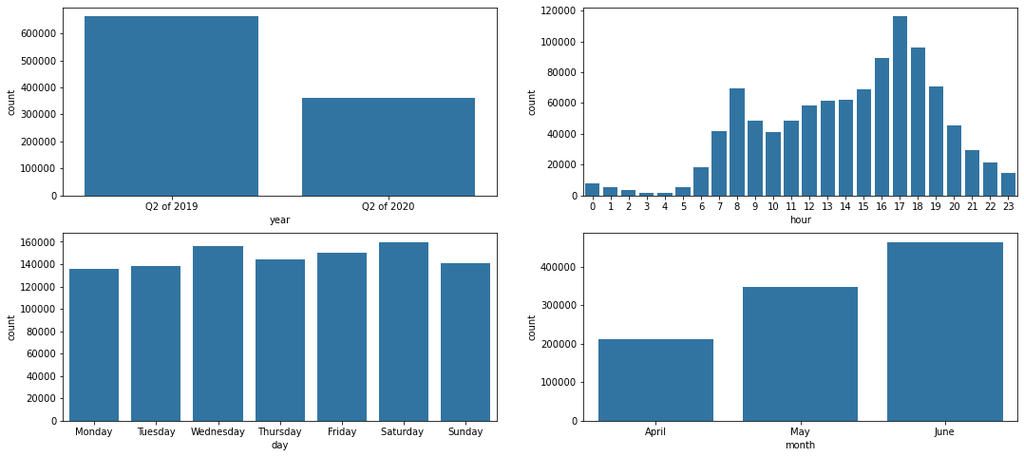

```python
#plot count plot for the catigorical variables
fig , ax = plt.subplots(nrows = 2 , ncols = 2 , figsize = [18,8])
default_color = sb.color_palette()[0]

sb.countplot(data = df , x = 'year' , color = default_color , ax=ax[0,0]);
sb.countplot(data = df , x = 'hour' , color = default_color , ax=ax[0,1]);
sb.countplot(data = df , x = 'day' , color = default_color , ax=ax[1,0]);
sb.countplot(data = df , x = 'month' , color = default_color , ax=ax[1,1]);
```

Year : It's clear that the total number of bikeshare before Pandemic at 2019 was much higher than during 2020  
Hour : For the hour distribution, the peak at 5:00 pm , i think that's rush hour for people going back from work  
followed by 8:00 am when people going from home to work , I am intrested to find out the lock down impact later  
Day of the week : no clear diffrence between working day and holiday  
Month: it increased from April to June , I think the reason is the beginning of the pendemic was at April 2020

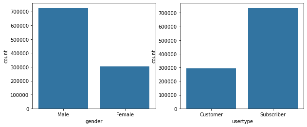

```python
fig , ax = plt.subplots(ncols = 2 , figsize = [10,4])

default_color = sb.color_palette()[0]
sb.countplot(data = df , x = 'gender' , color = default_color , ax=ax[0]);
sb.countplot(data = df , x = 'usertype' , color = default_color , ax=ax[1]);
```

Males using bikes more then females  
Subscriber using bikes more than customer  
what would be the impact of Covid-19 on both of gender and user type!

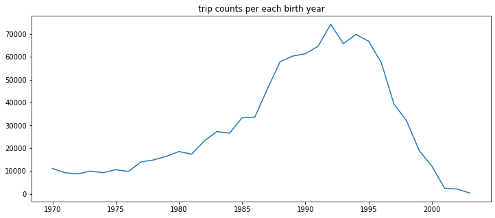

```python
df['birth year'].value_counts().sort_index().plot.line(figsize = (12,5))
plt.title('trip counts per each birth year')
```

### Of the features you investigated, were there any unusual distributions? Did you perform any operations on the data to tidy, adjust, or change the form of the data? If so, why did you do this?

> no unusual distribution found in the investigated features in this section  
> All data Wrangling had been done in the Preliminary Wrangling section

## Bivariate Exploration

> In this section, I will investigate variance in total trips count (before and during covid-19)  
> Also i will check which features effecting trips duration

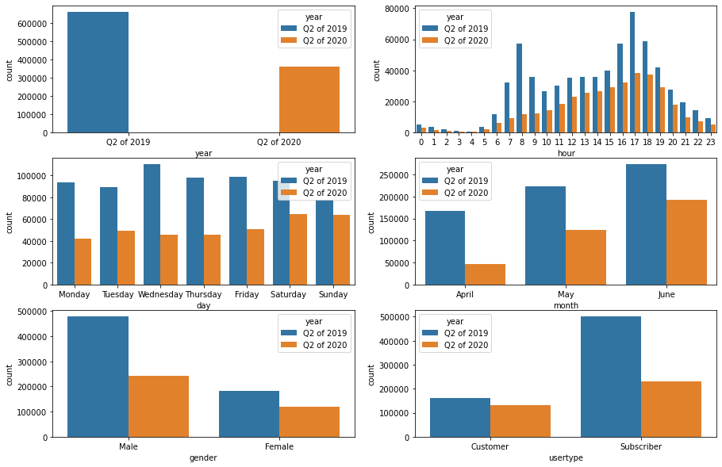

```python
fig , ax = plt.subplots(nrows = 3 , ncols = 2 , figsize = [15,10])


sb.countplot(data = df , x = 'year' , hue = 'year' , ax=ax[0,0]);
sb.countplot(data = df , x = 'hour' , hue = 'year' , ax=ax[0,1]);
sb.countplot(data = df , x = 'day' , hue = 'year' , ax=ax[1,0]);
sb.countplot(data = df , x = 'month' , hue = 'year' , ax=ax[1,1]);
sb.countplot(data = df , x = 'gender' , hue = 'year' , ax=ax[2,0]);
sb.countplot(data = df , x = 'usertype' , hue = 'year' , ax=ax[2,1]);
```

Hour: big diffrence in number of tips specially at 8:00 am , i think that's becouse the lockdown and most of people was working from home  
Month : big diffrence in number of tips specially in April at the beginning of the pendemic, peaple were panicked  
Gender : the impact of the pandemic in Male is much more on female  
User type : subscriber reduced to half number , however the customer didn't show a big impact  
I am intrested to dig litter deeper to find the relation between the gender and the user type

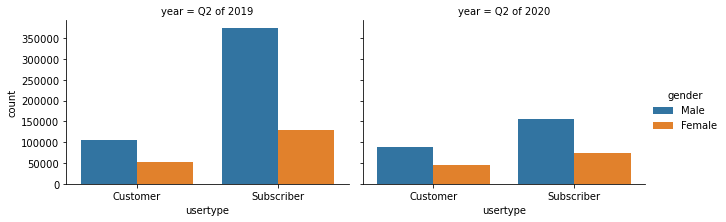

```python
g = sb.catplot(x="usertype", col="year",
                data=df, hue="gender"
                 , kind="count", height = 3, aspect = 1.5 )
```

Male subscriber stayed at home

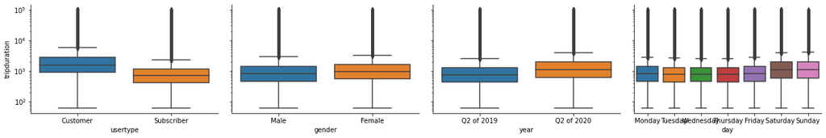

```python
#plot matrix of categorical features against trip duration.
def boxgrid (x , y , **Kwargs):
    sb.boxplot(x , y )
plt.figure(figsize = [10,10])
g = sb.PairGrid( data = df , y_vars = 'tripduration' , x_vars = ['usertype' , 'gender' , 'year'  , 'day' ] , height = 3, aspect = 1.5)
g.map(boxgrid)
plt.yscale('log')
plt.show();
```

Trip duration for customer is hieghr than the subscriber

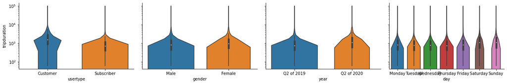

```python
def violin (x , y , **Kwargs):
    sb.violinplot(x , y )
plt.figure(figsize = [10,10])
g = sb.PairGrid( data = df , y_vars = 'tripduration' , x_vars = ['usertype' , 'gender' , 'year' , 'day' ]  , size = 3, aspect = 1.5)
g.map(violin)
plt.yscale('log')
plt.show();
```

Trip duration for customer is hieghr than the subscriber

```python
# compute the logarithm of price to make multivariate plotting easier
def log_trans(x, inverse = False):
    """ quick function for computing log and power operations """
    if not inverse:
        return np.log10(x)
    else:
        return np.power(10, x)

df['log_tripduration'] = df['tripduration'].apply(log_trans)
```

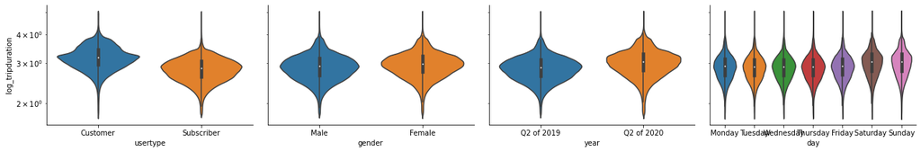

```python
def violin (x , y , **Kwargs):
    sb.violinplot(x , y )
plt.figure(figsize = [10,10])
g = sb.PairGrid( data = df , y_vars = 'log_tripduration' , x_vars = ['usertype' , 'gender' , 'year' , 'day' ]  , size = 3, aspect = 1.5)
g.map(violin)
plt.yscale('log')
plt.show();
```

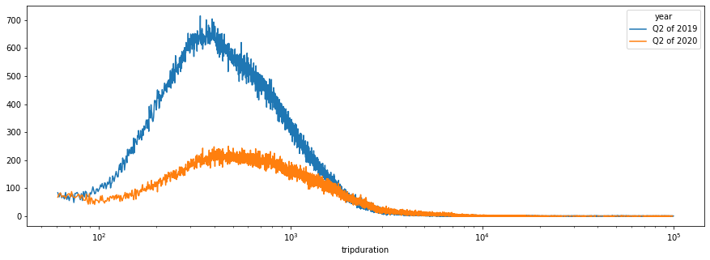

```python
p=df.groupby([ 'tripduration' , 'year']).size().reset_index().pivot(columns=['year'], index='tripduration', values=0)
p.plot(figsize = (15,5))
plt.xscale('log')
```

However the number counts of trips in 2019 is much higher , It is interesting to see the trend lines indicating longer average trip durations during covid-19 more than the no-covid period.

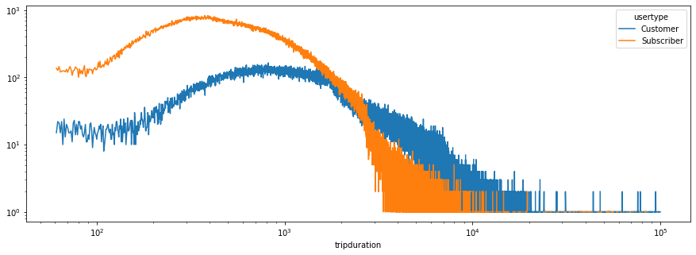

```python
p=df.groupby([ 'tripduration' , 'usertype']).size().reset_index().pivot(columns=['usertype'], index='tripduration', values=0)
p.plot(figsize = (15,5))
plt.xscale('log')
plt.yscale('log')
```

However the number counts of subscriber trips is much higher , It is interesting to see the lines indicating the customer trip duration average is higher than the subscriber